# ST0249 AI & Machine Learning Assignment 2

## PART B: Unsupervised Learning

## Topic: Iris Dataset Clustering

#### Name: Choo Weng Yan

#### Class: DIT/FT/2A/14

#### Admission Number: p1940208

```python
# Suppress Future Warnings
import warnings
#warnings.simplefilter(action='ignore', category=FutureWarning)
warnings.filterwarnings('ignore')
```

# Data Importing

```python
import sklearn
from sklearn import datasets
import numpy as np
import pandas as pd
from matplotlib import pyplot as plt
import seaborn as sns
import platform
%matplotlib inline

#show the versions of the libraries that are currently in use
message="        Versions        "
print("*"*len(message))
print(message)
print("*"*len(message))
print("Scikit-learn version={}".format(sklearn.__version__))
print("Numpy version={}".format(np.__version__))
print("Pandas version={}".format(pd.__version__))
print("Seaborn version={}".format(sns.__version__))
print("Python version={}".format(platform.python_version()))
```

```
        Versions
Scikit-learn version=0.20.3
Numpy version=1.16.2
Pandas version=0.23.4
Seaborn version=0.9.0
Python version=3.6.6
```

```python
#Import Iris Dataset
iris = datasets.load_iris()
X = iris.data
y = iris.target
```

```python
# concat iris['data'] and iris['target'] arrays into dataframe

iris_df = pd.DataFrame(data= np.c_[iris['data'], iris['target']],
                     columns= iris['feature_names'] + ['target'])

iris_df.head()
```

|  | sepal length (cm) | sepal width (cm) | petal length (cm) | petal width (cm) | target |
| --- | --- | --- | --- | --- | --- |
| 0 | 5.1 | 3.5 | 1.4 | 0.2 | 0.0 |
| 1 | 4.9 | 3.0 | 1.4 | 0.2 | 0.0 |
| 2 | 4.7 | 3.2 | 1.3 | 0.2 | 0.0 |
| 3 | 4.6 | 3.1 | 1.5 | 0.2 | 0.0 |
| 4 | 5.0 | 3.6 | 1.4 | 0.2 | 0.0 |

Here, the data in iris dataset is combined into a Data Frame using NumPy concatenate function so that it will be easier to plot the graphs for analysis.

```python
#drop 'target' as it will be the target variable in this analysis
iris_df=iris_df.drop(['target'], axis=1)
```

# Data Exploration

```python
#Showing all the information about the dataset

msg="Information of the Train Dataset"
print("*"*len(msg))
print(msg)
print("*"*len(msg))
print(iris_df.info())
print()

msg="Columns in the Train Dataset"
print("*"*len(msg))
print(msg)
print("*"*len(msg))
print(iris_df.columns)
print()

msg="Shape of the Train Dataset"
print("*"*len(msg))
print(msg)
print("*"*len(msg))
print(iris_df.shape)
print()

msg="Descriptive statistical summary of the train dataset is shown below: "
print("*"*len(msg))
print(msg)
print("*"*len(msg))
iris_df.describe()
```

```
Information of the Train Dataset
<class 'pandas.core.frame.DataFrame'>
RangeIndex: 150 entries, 0 to 149
Data columns (total 4 columns):
sepal length (cm)    150 non-null float64
sepal width (cm)     150 non-null float64
petal length (cm)    150 non-null float64
petal width (cm)     150 non-null float64
dtypes: float64(4)
memory usage: 4.8 KB
None

Columns in the Train Dataset
Index(['sepal length (cm)', 'sepal width (cm)', 'petal length (cm)',
       'petal width (cm)'],
      dtype='object')

Shape of the Train Dataset
(150, 4)

Descriptive statistical summary of the train dataset is shown below:
```

|  | sepal length (cm) | sepal width (cm) | petal length (cm) | petal width (cm) |
| --- | --- | --- | --- | --- |
| count | 150.000000 | 150.000000 | 150.000000 | 150.000000 |
| mean | 5.843333 | 3.057333 | 3.758000 | 1.199333 |
| std | 0.828066 | 0.435866 | 1.765298 | 0.762238 |
| min | 4.300000 | 2.000000 | 1.000000 | 0.100000 |
| 25% | 5.100000 | 2.800000 | 1.600000 | 0.300000 |
| 50% | 5.800000 | 3.000000 | 4.350000 | 1.300000 |
| 75% | 6.400000 | 3.300000 | 5.100000 | 1.800000 |
| max | 7.900000 | 4.400000 | 6.900000 | 2.500000 |

```python
#list out the missing values
iris_df.isnull().sum()
```

```
sepal length (cm)    0
sepal width (cm)     0
petal length (cm)    0
petal width (cm)     0
dtype: int64
```

It shows that there are no null values in this dataset. Hence, we can move further to the Exploratory Data Analysis.

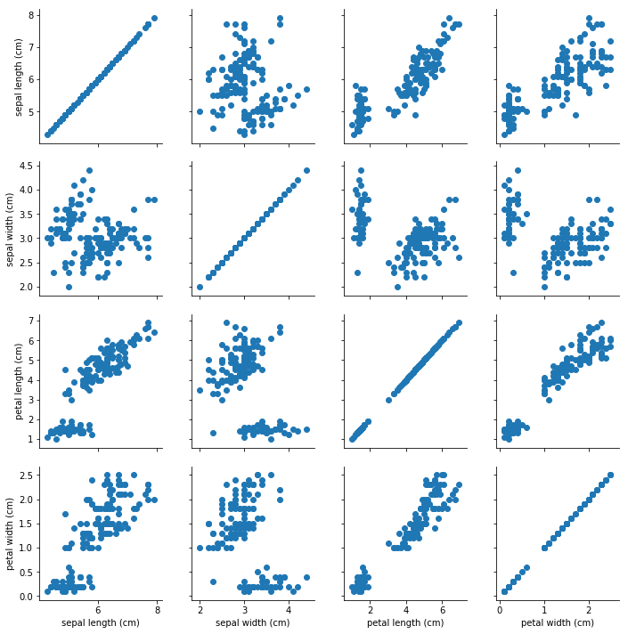

```python
g = sns.PairGrid(iris_df, palette=sns.color_palette("cubehelix", 3), vars=['sepal length (cm)','sepal width (cm)','petal length (cm)','petal width (cm)'])
g.map(plt.scatter)
plt.show()
```

The PairGrid graph shows the relationship between the sepal length, sepal width, petal length and petal width in the iris dataset.

We can observe that there is a decent correlation between petal length and petal width.

- Petal length and petal width are the most useful features to identify various flower types.
- While one of the cluster can be easily identified (linearly separable), while the other clusters have some overlap (almost linearly separable).

From the output, we can clearly see that there's a positive correlation between the petal length and petal width column which means it is a good indicator for clustering.

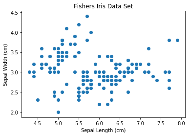

```python
plt.scatter(iris_df['sepal length (cm)'], iris_df['sepal width (cm)'])
plt.xlabel("Sepal Length (cm)")
plt.ylabel('Sepal Width (cm)')
plt.title('Fisher''s Iris Data Set');
```

Here, I am going to create some clustering models so that the iris can be separated based on their species (class)

```python
#put all the variables in iris dataset into 'features'

features = iris_df.loc[:,["sepal length (cm)","sepal width (cm)","petal length (cm)","petal width (cm)"]]
```

# Clustering Model

## Agglomerative Clustering

##### Find the optimum clusters (Hierarchy)

Before creating the model, optimum number of clusters have to be found so that we will get to know what number to put for n_clusters by using cluster hierarchy (dendrogram)

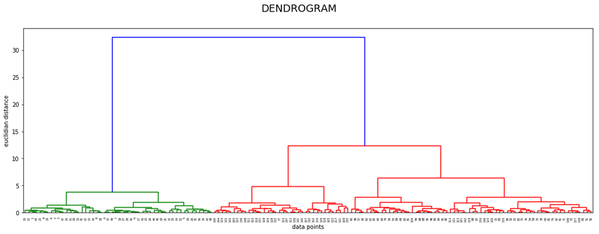

```python
from scipy.cluster.hierarchy import dendrogram, linkage

merg = linkage(features,method="ward")

plt.figure(figsize=(18,6))
dendrogram(merg, leaf_rotation=90)
plt.xlabel("data points")
plt.ylabel("euclidian distance")

plt.suptitle("DENDROGRAM",fontsize=18)
plt.show()
```

This shows that there 3 interceptions which represents the ideal amount of labels in Iris Dataset are divided into 3 clusters.

```python
from sklearn.cluster import AgglomerativeClustering

ac_model = AgglomerativeClustering(n_clusters=3, affinity='euclidean', linkage='ward')

pred_ac_iris= ac_model.fit_predict(X)
```

```python
pred_ac = ac_model.labels_
```

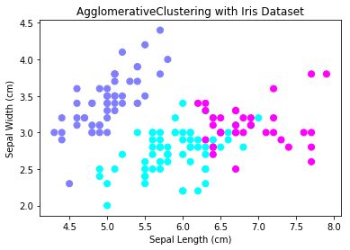

```python
plt.scatter(X[:, 0], X[:, 1], c=pred_ac_iris, s=50, cmap='cool')
plt.title('AgglomerativeClustering with Iris Dataset')
plt.xlabel('Sepal Length (cm)')
plt.ylabel('Sepal Width (cm)')
```

Based on the Dendrogram, the n_clusters for Agglomerative Clustering has set to 3.

The graph on the left shows the class/species clustering of the Iris Dataset based on the Agglomerative Clustering model.

It shows 3 clusters of iris with different colors based on the predicted iris species. It can be seen clearly that one of the iris species (purple color points) are linearly separated from the two other iris species.

While for the two other iris species (cyan and pink color points), some of the points are overlapping with each other but they are still clearly separated by the colors based on the predicted clusters.

```python
# calculate adjusted rand score

from sklearn import metrics
iris_ac_score = metrics.adjusted_rand_score(y,pred_ac_iris)

# Print the score
iris_ac_score
```

```
0.7311985567707745
```

Rand score for Agglomerative Clustering with 3 clusters has calculated to see how well did it do. The score shows 0.73

## K Means Clustering

### The Elbow Method/ Screeplot

#### Find the best value for k in K-means classification

Before creating the K-Means model, optimum number of clusters have to be found so that we will get to know what number to put for n_clusters by using screeplot (also known as the Elbow Method)

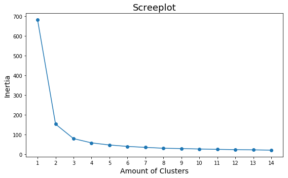

```python
from sklearn.cluster import KMeans
wcss = []

for k in range(1,15):
    kmeans = KMeans(n_clusters=k)
    kmeans.fit(features)
    wcss.append(kmeans.inertia_)


plt.figure(figsize=(8,5))
plt.title("Screeplot", fontsize=18)
plt.plot(range(1,15),wcss,"-o")
# plt.grid(True)
plt.xlabel("Amount of Clusters",fontsize=14)
plt.ylabel("Inertia",fontsize=14)
plt.xticks(range(1,15))
plt.tight_layout()
plt.show()
```

The graph on the above shows the screeplot to show the best number to put for K-Means Clustering.

Based on the elbow rule, the optimum clusters is where the elbow occurs and it's when the within cluster sum of squares (WCSS) does not decrease significantly every iteration.

Hence, it seems like 3 or 2 will be the best value for clusters.

### Silhouette Score

```python
# Clustering silhouette_score
from sklearn.metrics import silhouette_score

for n_cluster in range(2, 11):
    kmeans = KMeans(n_clusters=n_cluster).fit(X)
    label = kmeans.labels_
    sil_coeff = silhouette_score(X, label, metric='euclidean')
    print("For n_clusters={}, The Silhouette Coefficient is {}".format(
            n_cluster, sil_coeff))
```

```
For n_clusters=2, The Silhouette Coefficient is 0.681046169211746
For n_clusters=3, The Silhouette Coefficient is 0.5528190123564091
For n_clusters=4, The Silhouette Coefficient is 0.4980505049972867
For n_clusters=5, The Silhouette Coefficient is 0.4887488870931048
For n_clusters=6, The Silhouette Coefficient is 0.3648340039670018
For n_clusters=7, The Silhouette Coefficient is 0.35652851519897705
For n_clusters=8, The Silhouette Coefficient is 0.35974549238457515
For n_clusters=9, The Silhouette Coefficient is 0.3092968167529719
For n_clusters=10, The Silhouette Coefficient is 0.3171863896420686
```

The silhouette coefficient method measures the quality of clustering by determining how well a data point lies within its cluster. A high average silhouette indicates good clustering.

After the iterations, it shows that K-Means Clustering with 2 or 3 n_clusters have the highest Silhouette Score which has the closest score to 1.

Hence, I will use 2 and 3 n_clusters to predict the iris species and see which clusters gets a higher rand score.

```python
#fit K means model to the data (2 clusters)
from sklearn.cluster import KMeans
km2 = KMeans(n_clusters=2, random_state=46)
km2.fit(X)
print(km2)

# predict labels for sample data using trained model
y_km2 = km2.predict(X)
```

```
KMeans(algorithm='auto', copy_x=True, init='k-means++', max_iter=300,
    n_clusters=2, n_init=10, n_jobs=None, precompute_distances='auto',
    random_state=46, tol=0.0001, verbose=0)
```

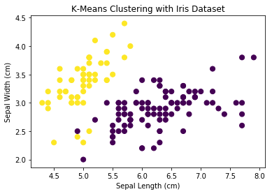

```python
#Visualising the clusters (2 clusters)

#sepal width and sepal length
plt.scatter(X[:, 0], X[:, 1], c=y_km2, s=50, cmap='viridis')
plt.title('K-Means Clustering with Iris Dataset')
plt.xlabel('Sepal Length (cm)')
plt.ylabel('Sepal Width (cm)')
```

Based on the score plot and the silhouette score in the previous slides, the n_clusters for K-Means Clustering has set to 2.

The graph on the left shows the class/species clustering of the Iris Dataset based on the K-Means Clustering model.

However, there are still a very small number of overlapping points (species) from the yellow points at the purple points clusters.

```python
from sklearn.metrics.cluster import adjusted_rand_score

#see how the k-means clustering (2 clusters) did
iris_km2_score = adjusted_rand_score(y, y_km2)
iris_km2_score
```

```
0.5399218294207123
```

Rand score for K-Means Clustering with 2 clusters has calculated to see how well did it do. The score shows 0.54

```python
#fit K means model to the data (3 clusters)
from sklearn.cluster import KMeans
km = KMeans(n_clusters=3, random_state=46)
km.fit(X)
print(km)

# predict labels for sample data using trained model
y_km = km.predict(X)
```

```
KMeans(algorithm='auto', copy_x=True, init='k-means++', max_iter=300,
    n_clusters=3, n_init=10, n_jobs=None, precompute_distances='auto',
    random_state=46, tol=0.0001, verbose=0)
```

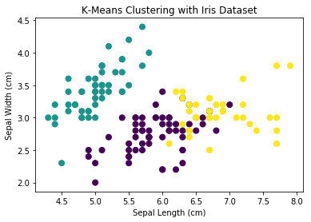

```python
#Visualising the clusters (3 clusters)

#sepal width and sepal length
plt.scatter(X[:, 0], X[:, 1], c=y_km, s=50, cmap='viridis')
plt.title('K-Means Clustering with Iris Dataset')
plt.xlabel('Sepal Length (cm)')
plt.ylabel('Sepal Width (cm)')
```

Based on the score plot and the silhouette score in the previous slides, the n_clusters for K-Means Clustering has set to 3.

The graph on the left shows the class/species clustering of the Iris Dataset based on the K-Means Clustering model.

However, there are still a very small number of overlapping points (species) from the yellow points at the purple points clusters.

```python
from sklearn.metrics.cluster import adjusted_rand_score

#see how the k-means clustering (3 clusters) did
iris_km_score = adjusted_rand_score(y, y_km)
iris_km_score
```

```
0.7302382722834697
```

Rand score for K-Means Clustering with 3 clusters has calculated to see how well did it do. The score shows 0.73 which is 0.19 higher than rand score with 2 clusters.

It shows clearly that K-Means Clustering with 3 clusters are more accurate compared to 2 clusters in Iris Dataset

## Gaussian Mixture Model

```python
# 2 components
from sklearn.mixture import GaussianMixture

#Gaussian Mixture Model
gmm2 = GaussianMixture(n_components=2)
pred_gmm_iris2 =gmm2.fit_predict(X)
proba_lists2 = gmm2.predict_proba(X)
```

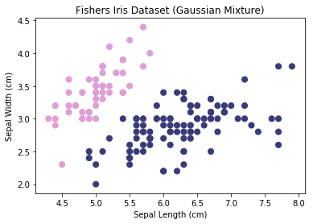

```python
# 2 components
plt.scatter(X[:, 0], X[:, 1], c=pred_gmm_iris2, s=50, cmap='tab20b')
plt.xlabel('Sepal Length (cm)')
plt.ylabel('Sepal Width (cm)')
plt.title ('Fishers Iris Dataset (Gaussian Mixture)')
```

The graph on the above shows the class/species clustering of the Iris Dataset based on the Gaussian Mixture model.

```python
# calculate adjusted rand score (2 components)
from sklearn import metrics

iris_gmm2_score = metrics.adjusted_rand_score(y,pred_gmm_iris2)

# Print the score
iris_gmm2_score
```

```
0.5681159420289855
```

Rand score for Gaussian Mixture with 2 clusters has calculated to see how well did it do. The score shows 0.57

```python
# 3 components

from sklearn.mixture import GaussianMixture

#Gaussian Mixture Model
gmm = GaussianMixture(n_components=3)
pred_gmm_iris =gmm.fit_predict(X)
proba_lists = gmm.predict_proba(X)
```

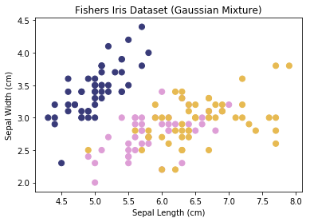

```python
#3 components
plt.scatter(X[:, 0], X[:, 1], c=pred_gmm_iris, s=50, cmap='tab20b')
plt.xlabel('Sepal Length (cm)')
plt.ylabel('Sepal Width (cm)')
plt.title ('Fishers Iris Dataset (Gaussian Mixture)')
```

The graph on the above shows the class/species clustering of the Iris Dataset based on the Gaussian Mixture model.

However, there are overlapping points within 2 clusters of iris species which are the pink clusters and the orange clusters.

```python
#calculate adjusted rand score (3 components)
from sklearn import metrics

iris_gmm_score = metrics.adjusted_rand_score(y,pred_gmm_iris)

# Print the score
iris_gmm_score
```

```
0.9038742317748124
```

Rand score for Gaussian Mixture with 3 clusters has calculated to see how well did it do. The score shows 0.90 which is 0.34 higher than rand score with 2 clusters.

It shows clearly that Gaussian Mixture with 3 clusters are more accurate compared to 2 clusters in Iris Dataset

## K-Means Clustering Algorithm using PCA

```python
#scaling the data before PCA
#standardized the variables -> Z values

from sklearn.preprocessing import scale
iris_reduced=pd.DataFrame(scale(iris_df),columns=["sepal length (cm)","sepal width (cm)","petal length (cm)","petal width (cm)"])
iris_reduced.head()
```

|  | sepal length (cm) | sepal width (cm) | petal length (cm) | petal width (cm) |
| --- | --- | --- | --- | --- |
| 0 | -0.900681 | 1.019004 | -1.340227 | -1.315444 |
| 1 | -1.143017 | -0.131979 | -1.340227 | -1.315444 |
| 2 | -1.385353 | 0.328414 | -1.397064 | -1.315444 |
| 3 | -1.506521 | 0.098217 | -1.283389 | -1.315444 |
| 4 | -1.021849 | 1.249201 | -1.340227 | -1.315444 |

```python
from sklearn.decomposition import PCA

#choose 2 PCs
pca = PCA(n_components=2, whiten=True).fit(iris_reduced)
X_pca = pca.transform(iris_reduced)
X_pca2=np.dot(iris_reduced, pca.components_.T)
X_pca2 = pd.DataFrame(X_pca2, columns=['PC1','PC2'])
X_pca2.head(5)
```

|  | PC1 | PC2 |
| --- | --- | --- |
| 0 | -2.264703 | 0.480027 |
| 1 | -2.080961 | -0.674134 |
| 2 | -2.364229 | -0.341908 |
| 3 | -2.299384 | -0.597395 |
| 4 | -2.389842 | 0.646835 |

```python
from sklearn.cluster import KMeans
km_pca= KMeans(n_clusters=3, init='k-means++', random_state = 42)
```

```python
km_pca=km_pca.fit(X_pca2)
y_km_pca = km_pca.predict(X_pca2)
```

```python
X_pca_km = pd.concat([iris_df.reset_index(drop=True), X_pca2], axis=1)

#the last column contains the pca k-means predicted clustering labels
X_pca_km['PCA Clusters'] = y_km_pca
```

```python
X_pca_km.head()
```

|  | sepal length (cm) | sepal width (cm) | petal length (cm) | petal width (cm) | PC1 | PC2 | PCA Clusters |
| --- | --- | --- | --- | --- | --- | --- | --- |
| 0 | 5.1 | 3.5 | 1.4 | 0.2 | -2.264703 | 0.480027 | 1 |
| 1 | 4.9 | 3.0 | 1.4 | 0.2 | -2.080961 | -0.674134 | 1 |
| 2 | 4.7 | 3.2 | 1.3 | 0.2 | -2.364229 | -0.341908 | 1 |
| 3 | 4.6 | 3.1 | 1.5 | 0.2 | -2.299384 | -0.597395 | 1 |
| 4 | 5.0 | 3.6 | 1.4 | 0.2 | -2.389842 | 0.646835 | 1 |

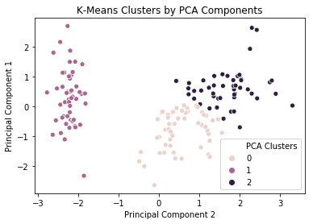

```python
#graph visualization with respect to the first two components.

sns.scatterplot(X_pca_km.PC1, X_pca_km.PC2, hue=X_pca_km['PCA Clusters'])
plt.ylabel('Principal Component 1')
plt.xlabel('Principal Component 2')
plt.title('K-Means Clusters by PCA Components')
plt.show()
```

The graph on the left shows the class/species clustering of the Iris Dataset based on the K-Means Clusters using PCA Components.

It shows 3 clusters of iris with different colors based on the predicted iris species. It can be seen clearly that PCA Clusters labeled ‘1’ is separated away from PCA Clusters 0 and 2.

While ‘PCA Clusters 0’ is very close to ‘PCA Clusters 2’. However, there is much more lesser overlapping points in this graph.

# Conclusion

Gaussian Mixture model seems to have the most accurate prediction of the iris species among the all the models as it gets 0.90 of the adjusted rand score.

Based on the Gaussian Mixture model, it predicts that there are 3 species in the iris as the data points are plotted in 3 different clusters with different colors on it.

One of the species can be easily clustered based on sepal length and sepal width as they can be linearly separated easily. While the other two species of iris are more difficult to be clustered as they overlap with each other.

In conclusion, Gaussian Mixture model managed to predict 3 clusters in iris dataset with the rand score of 0.90

# References

https://fallfordata.com/soft-clustering-with-gaussian-mixture-models-gmm/

https://easyai.tech/en/blog/unsupervised-learning-with-python/

https://www.bogotobogo.com/python/scikit-learn/scikit_machine_learning_Unsupervised_Learning_Clustering.php

https://365datascience.com/pca-k-means/

https://programming.rhysshea.com/GMM_clustering/

https://towardsdatascience.com/clustering-based-unsupervised-learning-8d705298ae51